# Risk Factor Analysis

## Outcome Variable

**Outcome Variable:** whz

## Predictor Variables

**Intervention Variable:** exclfeed3

**Adjustment Set:**

- arm
- sex
- W_mage
- meducyrs
- feducyrs
- hhwealth_quart
- hfoodsec
- W_mhtcm
- vagbrth
- W_gagebrth
- W_birthwt
- W_birthlen
- W_nrooms
- W_nchldlt5
- month
- brthmon
- W_parity
- impfloor
- impsan
- safeh20
- delta_W_mage
- delta_meducyrs
- delta_feducyrs
- delta_hhwealth_quart
- delta_hfoodsec
- delta_W_mhtcm
- delta_vagbrth
- delta_W_gagebrth
- delta_W_birthwt
- delta_W_birthlen
- delta_W_nrooms
- delta_W_nchldlt5
- delta_month
- delta_brthmon
- delta_W_parity
- delta_impfloor
- delta_impsan
- delta_safeh20

## Stratifying Variables

The analysis was stratified on these variable(s):

- agecat
- studyid
- country

## Data Summary

| agecat | studyid | country | exclfeed3 | n_cell | n |
| --- | --- | --- | --- | --- | --- |
| Birth | ki0047075b-MAL-ED | BANGLADESH | 1 | 164 | 227 |
| Birth | ki0047075b-MAL-ED | BANGLADESH | 0 | 63 | 227 |
| Birth | ki0047075b-MAL-ED | BRAZIL | 1 | 65 | 177 |
| Birth | ki0047075b-MAL-ED | BRAZIL | 0 | 112 | 177 |
| Birth | ki0047075b-MAL-ED | INDIA | 1 | 121 | 193 |
| Birth | ki0047075b-MAL-ED | INDIA | 0 | 72 | 193 |
| Birth | ki0047075b-MAL-ED | NEPAL | 1 | 60 | 166 |
| Birth | ki0047075b-MAL-ED | NEPAL | 0 | 106 | 166 |
| Birth | ki0047075b-MAL-ED | PERU | 1 | 64 | 265 |
| Birth | ki0047075b-MAL-ED | PERU | 0 | 201 | 265 |
| Birth | ki0047075b-MAL-ED | SOUTH AFRICA | 1 | 32 | 231 |
| Birth | ki0047075b-MAL-ED | SOUTH AFRICA | 0 | 199 | 231 |
| Birth | ki0047075b-MAL-ED | TANZANIA, UNITED REPUBLIC OF | 1 | 38 | 114 |
| Birth | ki0047075b-MAL-ED | TANZANIA, UNITED REPUBLIC OF | 0 | 76 | 114 |
| Birth | ki1000108-CMC-V-BCS-2002 | INDIA | 1 | 4 | 4 |
| Birth | ki1000108-CMC-V-BCS-2002 | INDIA | 0 | 0 | 4 |
| Birth | ki1000108-IRC | INDIA | 1 | 0 | 9 |
| Birth | ki1000108-IRC | INDIA | 0 | 9 | 9 |
| Birth | ki1000109-EE | PAKISTAN | 1 | 1 | 1 |
| Birth | ki1000109-EE | PAKISTAN | 0 | 0 | 1 |
| Birth | ki1000304b-SAS-CompFeed | INDIA | 1 | 45 | 47 |
| Birth | ki1000304b-SAS-CompFeed | INDIA | 0 | 2 | 47 |
| Birth | ki1101329-Keneba | GAMBIA | 1 | 1150 | 1305 |
| Birth | ki1101329-Keneba | GAMBIA | 0 | 155 | 1305 |
| Birth | kiGH5241-JiVitA-3 | BANGLADESH | 1 | 13731 | 15136 |
| Birth | kiGH5241-JiVitA-3 | BANGLADESH | 0 | 1405 | 15136 |
| Birth | kiGH5241-JiVitA-4 | BANGLADESH | 1 | 28 | 31 |
| Birth | kiGH5241-JiVitA-4 | BANGLADESH | 0 | 3 | 31 |
| 6 months | ki0047075b-MAL-ED | BANGLADESH | 1 | 172 | 237 |
| 6 months | ki0047075b-MAL-ED | BANGLADESH | 0 | 65 | 237 |

[output cut: 58 more lines]

The following strata were considered:

- agecat: 24 months, studyid: ki0047075b-MAL-ED, country: BANGLADESH
- agecat: 24 months, studyid: ki0047075b-MAL-ED, country: BRAZIL
- agecat: 24 months, studyid: ki0047075b-MAL-ED, country: INDIA
- agecat: 24 months, studyid: ki0047075b-MAL-ED, country: NEPAL
- agecat: 24 months, studyid: ki0047075b-MAL-ED, country: PERU
- agecat: 24 months, studyid: ki0047075b-MAL-ED, country: SOUTH AFRICA
- agecat: 24 months, studyid: ki0047075b-MAL-ED, country: TANZANIA, UNITED REPUBLIC OF
- agecat: 24 months, studyid: ki1000108-CMC-V-BCS-2002, country: INDIA
- agecat: 24 months, studyid: ki1000108-IRC, country: INDIA
- agecat: 24 months, studyid: ki1017093b-PROVIDE, country: BANGLADESH
- agecat: 24 months, studyid: ki1101329-Keneba, country: GAMBIA
- agecat: 24 months, studyid: ki1113344-GMS-Nepal, country: NEPAL
- agecat: 24 months, studyid: kiGH5241-JiVitA-3, country: BANGLADESH
- agecat: 24 months, studyid: kiGH5241-JiVitA-4, country: BANGLADESH
- agecat: 6 months, studyid: ki0047075b-MAL-ED, country: BANGLADESH
- agecat: 6 months, studyid: ki0047075b-MAL-ED, country: BRAZIL
- agecat: 6 months, studyid: ki0047075b-MAL-ED, country: INDIA
- agecat: 6 months, studyid: ki0047075b-MAL-ED, country: NEPAL
- agecat: 6 months, studyid: ki0047075b-MAL-ED, country: PERU
- agecat: 6 months, studyid: ki0047075b-MAL-ED, country: SOUTH AFRICA
- agecat: 6 months, studyid: ki0047075b-MAL-ED, country: TANZANIA, UNITED REPUBLIC OF
- agecat: 6 months, studyid: ki1000108-CMC-V-BCS-2002, country: INDIA
- agecat: 6 months, studyid: ki1000108-IRC, country: INDIA
- agecat: 6 months, studyid: ki1000109-EE, country: PAKISTAN
- agecat: 6 months, studyid: ki1000304b-SAS-CompFeed, country: INDIA
- agecat: 6 months, studyid: ki1017093b-PROVIDE, country: BANGLADESH
- agecat: 6 months, studyid: ki1101329-Keneba, country: GAMBIA
- agecat: 6 months, studyid: ki1113344-GMS-Nepal, country: NEPAL
- agecat: 6 months, studyid: kiGH5241-JiVitA-3, country: BANGLADESH
- agecat: 6 months, studyid: kiGH5241-JiVitA-4, country: BANGLADESH
- agecat: Birth, studyid: ki0047075b-MAL-ED, country: BANGLADESH
- agecat: Birth, studyid: ki0047075b-MAL-ED, country: BRAZIL
- agecat: Birth, studyid: ki0047075b-MAL-ED, country: INDIA
- agecat: Birth, studyid: ki0047075b-MAL-ED, country: NEPAL
- agecat: Birth, studyid: ki0047075b-MAL-ED, country: PERU
- agecat: Birth, studyid: ki0047075b-MAL-ED, country: SOUTH AFRICA
- agecat: Birth, studyid: ki0047075b-MAL-ED, country: TANZANIA, UNITED REPUBLIC OF
- agecat: Birth, studyid: ki1000108-CMC-V-BCS-2002, country: INDIA
- agecat: Birth, studyid: ki1000108-IRC, country: INDIA
- agecat: Birth, studyid: ki1000109-EE, country: PAKISTAN
- agecat: Birth, studyid: ki1000304b-SAS-CompFeed, country: INDIA
- agecat: Birth, studyid: ki1101329-Keneba, country: GAMBIA
- agecat: Birth, studyid: kiGH5241-JiVitA-3, country: BANGLADESH
- agecat: Birth, studyid: kiGH5241-JiVitA-4, country: BANGLADESH

### Dropped Strata

Some strata were dropped due to rare outcomes:

- agecat: Birth, studyid: ki1000108-CMC-V-BCS-2002, country: INDIA
- agecat: Birth, studyid: ki1000108-IRC, country: INDIA
- agecat: Birth, studyid: ki1000109-EE, country: PAKISTAN
- agecat: Birth, studyid: ki1000304b-SAS-CompFeed, country: INDIA
- agecat: Birth, studyid: kiGH5241-JiVitA-4, country: BANGLADESH
- agecat: 6 months, studyid: ki1000108-CMC-V-BCS-2002, country: INDIA
- agecat: 6 months, studyid: ki1000108-IRC, country: INDIA
- agecat: 24 months, studyid: ki1000108-CMC-V-BCS-2002, country: INDIA
- agecat: 24 months, studyid: ki1000108-IRC, country: INDIA

## Methods Detail

We’re interested in the causal parameters $E[Y_a]$ for all values of $a \in \mathcal{A}$. These parameters represent the mean outcome if, possibly contrary to fact, we intervened to set all units to have $A=a$. Under the randomization and positivity assumptions, these are identified by the statistical parameters $\psi_a=E_W[E_{Y|A,W}(Y|A=a,W)]$. In addition, we’re interested in the mean of $Y$, $E[Y]$ under no intervention (the observed mean). We will estimate these parameters by using SuperLearner to fit the relevant likelihood factors – $E_{Y|A,W}(Y|A=a,W)$ and $p(A=a|W)$, and then updating our likelihood fit using a joint TMLE.

For unadjusted analyses ($W=\{\}$), initial likelihoods were estimated using Lrnr_glm to estimate the simple $E(Y|A)$ and Lrnr_mean to estimate $p(A)$. For adjusted analyses, a small library containing Lrnr_glmnet, Lrnr_xgboost, and Lrnr_mean was used.

Having estimated these parameters, we will then use the delta method to estimate relative risks and attributable risks relative to a prespecified baseline level of $A$.

# Results Detail

## Results Plots

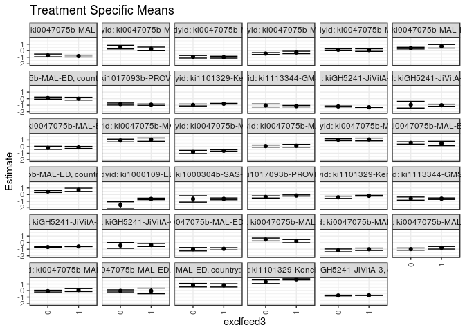

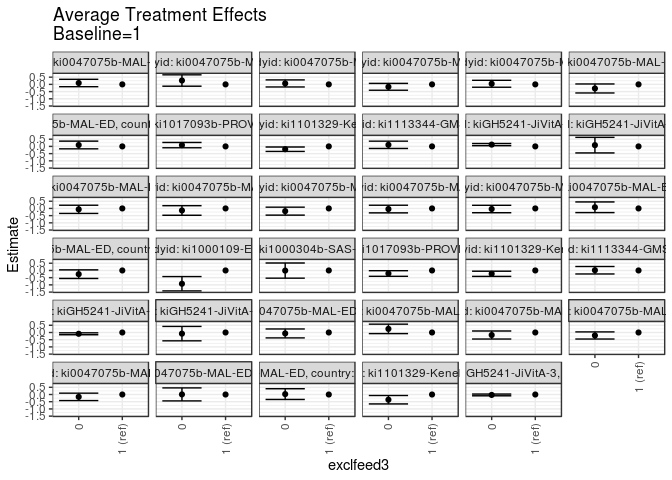

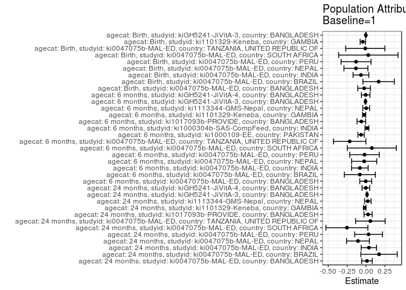

## Results Table

### Parameter: TSM

| agecat | studyid | country | intervention_level | baseline_level | estimate | ci_lower | ci_upper |
| --- | --- | --- | --- | --- | --- | --- | --- |
| Birth | ki0047075b-MAL-ED | BANGLADESH | 1 | NA | -0.9448164 | -1.1116786 | -0.7779541 |
| Birth | ki0047075b-MAL-ED | BANGLADESH | 0 | NA | -1.0097654 | -1.2698708 | -0.7496601 |
| Birth | ki0047075b-MAL-ED | BRAZIL | 1 | NA | 0.2178191 | -0.0349980 | 0.4706361 |
| Birth | ki0047075b-MAL-ED | BRAZIL | 0 | NA | 0.4676321 | 0.2402816 | 0.6949826 |
| Birth | ki0047075b-MAL-ED | INDIA | 1 | NA | -1.0151290 | -1.1979778 | -0.8322802 |
| Birth | ki0047075b-MAL-ED | INDIA | 0 | NA | -1.1912860 | -1.4096588 | -0.9729131 |
| Birth | ki0047075b-MAL-ED | NEPAL | 1 | NA | -0.7843740 | -0.9833499 | -0.5853981 |
| Birth | ki0047075b-MAL-ED | NEPAL | 0 | NA | -0.9922241 | -1.1646960 | -0.8197521 |
| Birth | ki0047075b-MAL-ED | PERU | 1 | NA | 0.0767046 | -0.1432930 | 0.2967022 |
| Birth | ki0047075b-MAL-ED | PERU | 0 | NA | -0.0859629 | -0.2199821 | 0.0480564 |
| Birth | ki0047075b-MAL-ED | SOUTH AFRICA | 1 | NA | -0.0591367 | -0.4815715 | 0.3632982 |
| Birth | ki0047075b-MAL-ED | SOUTH AFRICA | 0 | NA | -0.0520768 | -0.2117981 | 0.1076446 |
| Birth | ki0047075b-MAL-ED | TANZANIA, UNITED REPUBLIC OF | 1 | NA | 0.7969813 | 0.5433249 | 1.0506376 |
| Birth | ki0047075b-MAL-ED | TANZANIA, UNITED REPUBLIC OF | 0 | NA | 0.8248862 | 0.5542802 | 1.0954921 |
| Birth | ki1101329-Keneba | GAMBIA | 1 | NA | 1.7081572 | 1.6186232 | 1.7976913 |
| Birth | ki1101329-Keneba | GAMBIA | 0 | NA | 1.3470633 | 1.0691322 | 1.6249944 |
| Birth | kiGH5241-JiVitA-3 | BANGLADESH | 1 | NA | -0.7193957 | -0.7401106 | -0.6986808 |
| Birth | kiGH5241-JiVitA-3 | BANGLADESH | 0 | NA | -0.7483656 | -0.8071513 | -0.6895799 |
| 6 months | ki0047075b-MAL-ED | BANGLADESH | 1 | NA | -0.1200790 | -0.2738817 | 0.0337237 |
| 6 months | ki0047075b-MAL-ED | BANGLADESH | 0 | NA | -0.1829553 | -0.4226217 | 0.0567111 |
| 6 months | ki0047075b-MAL-ED | BRAZIL | 1 | NA | 1.0541998 | 0.7953980 | 1.3130017 |
| 6 months | ki0047075b-MAL-ED | BRAZIL | 0 | NA | 0.9133351 | 0.7018571 | 1.1248130 |
| 6 months | ki0047075b-MAL-ED | INDIA | 1 | NA | -0.6284404 | -0.7694521 | -0.4874287 |
| 6 months | ki0047075b-MAL-ED | INDIA | 0 | NA | -0.8170718 | -1.0538436 | -0.5803000 |
| 6 months | ki0047075b-MAL-ED | NEPAL | 1 | NA | 0.1263201 | -0.0869899 | 0.3396302 |
| 6 months | ki0047075b-MAL-ED | NEPAL | 0 | NA | 0.0834131 | -0.0786050 | 0.2454311 |
| 6 months | ki0047075b-MAL-ED | PERU | 1 | NA | 1.0780903 | 0.8630654 | 1.2931152 |
| 6 months | ki0047075b-MAL-ED | PERU | 0 | NA | 1.0381651 | 0.8921317 | 1.1841984 |
| 6 months | ki0047075b-MAL-ED | SOUTH AFRICA | 1 | NA | 0.4675362 | 0.1393352 | 0.7957372 |
| 6 months | ki0047075b-MAL-ED | SOUTH AFRICA | 0 | NA | 0.5483644 | 0.3782020 | 0.7185268 |
| 6 months | ki0047075b-MAL-ED | TANZANIA, UNITED REPUBLIC OF | 1 | NA | 0.7230950 | 0.4698095 | 0.9763806 |
| 6 months | ki0047075b-MAL-ED | TANZANIA, UNITED REPUBLIC OF | 0 | NA | 0.4659810 | 0.3112334 | 0.6207286 |
| 6 months | ki1000109-EE | PAKISTAN | 1 | NA | -0.6560116 | -0.7700527 | -0.5419705 |
| 6 months | ki1000109-EE | PAKISTAN | 0 | NA | -1.5773164 | -2.0611096 | -1.0935233 |
| 6 months | ki1000304b-SAS-CompFeed | INDIA | 1 | NA | -0.6465859 | -0.7848454 | -0.5083265 |
| 6 months | ki1000304b-SAS-CompFeed | INDIA | 0 | NA | -0.6556227 | -1.1386877 | -0.1725576 |
| 6 months | ki1017093b-PROVIDE | BANGLADESH | 1 | NA | -0.1463948 | -0.2425114 | -0.0502783 |
| 6 months | ki1017093b-PROVIDE | BANGLADESH | 0 | NA | -0.3570393 | -0.5254205 | -0.1886581 |
| 6 months | ki1101329-Keneba | GAMBIA | 1 | NA | -0.1808667 | -0.2392032 | -0.1225303 |
| 6 months | ki1101329-Keneba | GAMBIA | 0 | NA | -0.4129215 | -0.5847362 | -0.2411068 |
| 6 months | ki1113344-GMS-Nepal | NEPAL | 1 | NA | -0.6210909 | -0.7289223 | -0.5132596 |
| 6 months | ki1113344-GMS-Nepal | NEPAL | 0 | NA | -0.6044842 | -0.8401137 | -0.3688546 |
| 6 months | kiGH5241-JiVitA-3 | BANGLADESH | 1 | NA | -0.5852635 | -0.6060681 | -0.5644589 |
| 6 months | kiGH5241-JiVitA-3 | BANGLADESH | 0 | NA | -0.6759243 | -0.7394915 | -0.6123572 |
| 6 months | kiGH5241-JiVitA-4 | BANGLADESH | 1 | NA | -0.3610374 | -0.5873043 | -0.1347705 |
| 6 months | kiGH5241-JiVitA-4 | BANGLADESH | 0 | NA | -0.4410490 | -0.8813646 | -0.0007335 |
| 24 months | ki0047075b-MAL-ED | BANGLADESH | 1 | NA | -0.8200256 | -0.9677057 | -0.6723455 |
| 24 months | ki0047075b-MAL-ED | BANGLADESH | 0 | NA | -0.7240692 | -0.9347202 | -0.5134183 |
| 24 months | ki0047075b-MAL-ED | BRAZIL | 1 | NA | 0.2749693 | -0.0026658 | 0.5526044 |
| 24 months | ki0047075b-MAL-ED | BRAZIL | 0 | NA | 0.5443878 | 0.2624613 | 0.8263142 |
| 24 months | ki0047075b-MAL-ED | INDIA | 1 | NA | -0.9923580 | -1.1317174 | -0.8529986 |
| 24 months | ki0047075b-MAL-ED | INDIA | 0 | NA | -0.9269983 | -1.1278308 | -0.7261659 |
| 24 months | ki0047075b-MAL-ED | NEPAL | 1 | NA | -0.2723276 | -0.4581058 | -0.0865494 |
| 24 months | ki0047075b-MAL-ED | NEPAL | 0 | NA | -0.4407997 | -0.5855213 | -0.2960782 |
| 24 months | ki0047075b-MAL-ED | PERU | 1 | NA | 0.0910843 | -0.1080998 | 0.2902684 |
| 24 months | ki0047075b-MAL-ED | PERU | 0 | NA | 0.1342431 | -0.0057175 | 0.2742038 |
| 24 months | ki0047075b-MAL-ED | SOUTH AFRICA | 1 | NA | 0.6690062 | 0.3907369 | 0.9472755 |
| 24 months | ki0047075b-MAL-ED | SOUTH AFRICA | 0 | NA | 0.3855856 | 0.2532492 | 0.5179219 |
| 24 months | ki0047075b-MAL-ED | TANZANIA, UNITED REPUBLIC OF | 1 | NA | -0.0135276 | -0.2307292 | 0.2036740 |
| 24 months | ki0047075b-MAL-ED | TANZANIA, UNITED REPUBLIC OF | 0 | NA | 0.0846890 | -0.0703130 | 0.2396910 |
| 24 months | ki1017093b-PROVIDE | BANGLADESH | 1 | NA | -0.9149168 | -1.0124452 | -0.8173883 |
| 24 months | ki1017093b-PROVIDE | BANGLADESH | 0 | NA | -0.8242106 | -0.9809368 | -0.6674845 |
| 24 months | ki1101329-Keneba | GAMBIA | 1 | NA | -0.7749476 | -0.8291006 | -0.7207946 |
| 24 months | ki1101329-Keneba | GAMBIA | 0 | NA | -0.9698601 | -1.1146263 | -0.8250939 |
| 24 months | ki1113344-GMS-Nepal | NEPAL | 1 | NA | -1.1501236 | -1.2613826 | -1.0388646 |
| 24 months | ki1113344-GMS-Nepal | NEPAL | 0 | NA | -1.0396188 | -1.2650196 | -0.8142180 |
| 24 months | kiGH5241-JiVitA-3 | BANGLADESH | 1 | NA | -1.3157064 | -1.3409432 | -1.2904696 |
| 24 months | kiGH5241-JiVitA-3 | BANGLADESH | 0 | NA | -1.1912734 | -1.2624152 | -1.1201317 |
| 24 months | kiGH5241-JiVitA-4 | BANGLADESH | 1 | NA | -1.0113854 | -1.1724186 | -0.8503521 |
| 24 months | kiGH5241-JiVitA-4 | BANGLADESH | 0 | NA | -0.9237378 | -1.4380822 | -0.4093934 |

### Parameter: E(Y)

| agecat | studyid | country | intervention_level | baseline_level | estimate | ci_lower | ci_upper |
| --- | --- | --- | --- | --- | --- | --- | --- |
| Birth | ki0047075b-MAL-ED | BANGLADESH | NA | NA | -0.9701762 | -1.1093516 | -0.8310008 |
| Birth | ki0047075b-MAL-ED | BRAZIL | NA | NA | 0.3837288 | 0.2059602 | 0.5614974 |
| Birth | ki0047075b-MAL-ED | INDIA | NA | NA | -1.0824352 | -1.2259825 | -0.9388879 |
| Birth | ki0047075b-MAL-ED | NEPAL | NA | NA | -0.9184337 | -1.0582074 | -0.7786600 |
| Birth | ki0047075b-MAL-ED | PERU | NA | NA | -0.0558491 | -0.1687562 | 0.0570581 |
| Birth | ki0047075b-MAL-ED | SOUTH AFRICA | NA | NA | -0.0290476 | -0.1772448 | 0.1191495 |
| Birth | ki0047075b-MAL-ED | TANZANIA, UNITED REPUBLIC OF | NA | NA | 0.7865789 | 0.5832028 | 0.9899551 |
| Birth | ki1101329-Keneba | GAMBIA | NA | NA | 1.6646743 | 1.5791251 | 1.7502236 |
| Birth | kiGH5241-JiVitA-3 | BANGLADESH | NA | NA | -0.7222456 | -0.7423351 | -0.7021562 |
| 6 months | ki0047075b-MAL-ED | BANGLADESH | NA | NA | -0.1245816 | -0.2544517 | 0.0052886 |
| 6 months | ki0047075b-MAL-ED | BRAZIL | NA | NA | 0.9717225 | 0.8073791 | 1.1360658 |
| 6 months | ki0047075b-MAL-ED | INDIA | NA | NA | -0.7105222 | -0.8368775 | -0.5841669 |
| 6 months | ki0047075b-MAL-ED | NEPAL | NA | NA | 0.1010587 | -0.0308005 | 0.2329178 |
| 6 months | ki0047075b-MAL-ED | PERU | NA | NA | 1.0571296 | 0.9346064 | 1.1796528 |
| 6 months | ki0047075b-MAL-ED | SOUTH AFRICA | NA | NA | 0.5435551 | 0.3895443 | 0.6975659 |
| 6 months | ki0047075b-MAL-ED | TANZANIA, UNITED REPUBLIC OF | NA | NA | 0.5063403 | 0.3745918 | 0.6380888 |
| 6 months | ki1000109-EE | PAKISTAN | NA | NA | -0.7218667 | -0.8355727 | -0.6081607 |
| 6 months | ki1000304b-SAS-CompFeed | INDIA | NA | NA | -0.6348861 | -0.7630511 | -0.5067211 |
| 6 months | ki1017093b-PROVIDE | BANGLADESH | NA | NA | -0.2083706 | -0.2927992 | -0.1239419 |
| 6 months | ki1101329-Keneba | GAMBIA | NA | NA | -0.2057405 | -0.2614576 | -0.1500234 |
| 6 months | ki1113344-GMS-Nepal | NEPAL | NA | NA | -0.6194068 | -0.7173394 | -0.5214742 |
| 6 months | kiGH5241-JiVitA-3 | BANGLADESH | NA | NA | -0.5929896 | -0.6128338 | -0.5731455 |
| 6 months | kiGH5241-JiVitA-4 | BANGLADESH | NA | NA | -0.3657303 | -0.5647992 | -0.1666615 |
| 24 months | ki0047075b-MAL-ED | BANGLADESH | NA | NA | -0.8080769 | -0.9302432 | -0.6859106 |
| 24 months | ki0047075b-MAL-ED | BRAZIL | NA | NA | 0.4466272 | 0.2416144 | 0.6516401 |
| 24 months | ki0047075b-MAL-ED | INDIA | NA | NA | -0.9551111 | -1.0714034 | -0.8388188 |
| 24 months | ki0047075b-MAL-ED | NEPAL | NA | NA | -0.3795556 | -0.4938120 | -0.2652991 |
| 24 months | ki0047075b-MAL-ED | PERU | NA | NA | 0.1242714 | 0.0054301 | 0.2431126 |
| 24 months | ki0047075b-MAL-ED | SOUTH AFRICA | NA | NA | 0.4157543 | 0.2953789 | 0.5361297 |
| 24 months | ki0047075b-MAL-ED | TANZANIA, UNITED REPUBLIC OF | NA | NA | 0.0434286 | -0.0830724 | 0.1699295 |
| 24 months | ki1017093b-PROVIDE | BANGLADESH | NA | NA | -0.8879412 | -0.9708680 | -0.8050144 |
| 24 months | ki1101329-Keneba | GAMBIA | NA | NA | -0.7930925 | -0.8442611 | -0.7419240 |
| 24 months | ki1113344-GMS-Nepal | NEPAL | NA | NA | -1.1267450 | -1.2257791 | -1.0277110 |
| 24 months | kiGH5241-JiVitA-3 | BANGLADESH | NA | NA | -1.3031012 | -1.3269655 | -1.2792368 |
| 24 months | kiGH5241-JiVitA-4 | BANGLADESH | NA | NA | -1.0137086 | -1.1659964 | -0.8614208 |

### Parameter: ATE

| agecat | studyid | country | intervention_level | baseline_level | estimate | ci_lower | ci_upper |
| --- | --- | --- | --- | --- | --- | --- | --- |
| Birth | ki0047075b-MAL-ED | BANGLADESH | 1 | 1 | 0.0000000 | 0.0000000 | 0.0000000 |
| Birth | ki0047075b-MAL-ED | BANGLADESH | 0 | 1 | -0.0649491 | -0.3751521 | 0.2452539 |
| Birth | ki0047075b-MAL-ED | BRAZIL | 1 | 1 | 0.0000000 | 0.0000000 | 0.0000000 |
| Birth | ki0047075b-MAL-ED | BRAZIL | 0 | 1 | 0.2498130 | -0.0771297 | 0.5767557 |
| Birth | ki0047075b-MAL-ED | INDIA | 1 | 1 | 0.0000000 | 0.0000000 | 0.0000000 |
| Birth | ki0047075b-MAL-ED | INDIA | 0 | 1 | -0.1761570 | -0.4550355 | 0.1027216 |
| Birth | ki0047075b-MAL-ED | NEPAL | 1 | 1 | 0.0000000 | 0.0000000 | 0.0000000 |
| Birth | ki0047075b-MAL-ED | NEPAL | 0 | 1 | -0.2078501 | -0.4554813 | 0.0397812 |
| Birth | ki0047075b-MAL-ED | PERU | 1 | 1 | 0.0000000 | 0.0000000 | 0.0000000 |
| Birth | ki0047075b-MAL-ED | PERU | 0 | 1 | -0.1626675 | -0.4199964 | 0.0946614 |
| Birth | ki0047075b-MAL-ED | SOUTH AFRICA | 1 | 1 | 0.0000000 | 0.0000000 | 0.0000000 |
| Birth | ki0047075b-MAL-ED | SOUTH AFRICA | 0 | 1 | 0.0070599 | -0.4439006 | 0.4580204 |
| Birth | ki0047075b-MAL-ED | TANZANIA, UNITED REPUBLIC OF | 1 | 1 | 0.0000000 | 0.0000000 | 0.0000000 |
| Birth | ki0047075b-MAL-ED | TANZANIA, UNITED REPUBLIC OF | 0 | 1 | 0.0279049 | -0.3443638 | 0.4001736 |
| Birth | ki1101329-Keneba | GAMBIA | 1 | 1 | 0.0000000 | 0.0000000 | 0.0000000 |
| Birth | ki1101329-Keneba | GAMBIA | 0 | 1 | -0.3610939 | -0.6530936 | -0.0690942 |
| Birth | kiGH5241-JiVitA-3 | BANGLADESH | 1 | 1 | 0.0000000 | 0.0000000 | 0.0000000 |
| Birth | kiGH5241-JiVitA-3 | BANGLADESH | 0 | 1 | -0.0289699 | -0.0886089 | 0.0306691 |
| 6 months | ki0047075b-MAL-ED | BANGLADESH | 1 | 1 | 0.0000000 | 0.0000000 | 0.0000000 |
| 6 months | ki0047075b-MAL-ED | BANGLADESH | 0 | 1 | -0.0628763 | -0.3468325 | 0.2210799 |
| 6 months | ki0047075b-MAL-ED | BRAZIL | 1 | 1 | 0.0000000 | 0.0000000 | 0.0000000 |
| 6 months | ki0047075b-MAL-ED | BRAZIL | 0 | 1 | -0.1408648 | -0.4735681 | 0.1918386 |
| 6 months | ki0047075b-MAL-ED | INDIA | 1 | 1 | 0.0000000 | 0.0000000 | 0.0000000 |
| 6 months | ki0047075b-MAL-ED | INDIA | 0 | 1 | -0.1886314 | -0.4651232 | 0.0878604 |
| 6 months | ki0047075b-MAL-ED | NEPAL | 1 | 1 | 0.0000000 | 0.0000000 | 0.0000000 |
| 6 months | ki0047075b-MAL-ED | NEPAL | 0 | 1 | -0.0429070 | -0.3069423 | 0.2211282 |
| 6 months | ki0047075b-MAL-ED | PERU | 1 | 1 | 0.0000000 | 0.0000000 | 0.0000000 |
| 6 months | ki0047075b-MAL-ED | PERU | 0 | 1 | -0.0399252 | -0.2982527 | 0.2184023 |
| 6 months | ki0047075b-MAL-ED | SOUTH AFRICA | 1 | 1 | 0.0000000 | 0.0000000 | 0.0000000 |
| 6 months | ki0047075b-MAL-ED | SOUTH AFRICA | 0 | 1 | 0.0808282 | -0.2894761 | 0.4511324 |
| 6 months | ki0047075b-MAL-ED | TANZANIA, UNITED REPUBLIC OF | 1 | 1 | 0.0000000 | 0.0000000 | 0.0000000 |
| 6 months | ki0047075b-MAL-ED | TANZANIA, UNITED REPUBLIC OF | 0 | 1 | -0.2571141 | -0.5548428 | 0.0406147 |
| 6 months | ki1000109-EE | PAKISTAN | 1 | 1 | 0.0000000 | 0.0000000 | 0.0000000 |
| 6 months | ki1000109-EE | PAKISTAN | 0 | 1 | -0.9213048 | -1.4190465 | -0.4235631 |
| 6 months | ki1000304b-SAS-CompFeed | INDIA | 1 | 1 | 0.0000000 | 0.0000000 | 0.0000000 |
| 6 months | ki1000304b-SAS-CompFeed | INDIA | 0 | 1 | -0.0090367 | -0.5362411 | 0.5181676 |
| 6 months | ki1017093b-PROVIDE | BANGLADESH | 1 | 1 | 0.0000000 | 0.0000000 | 0.0000000 |
| 6 months | ki1017093b-PROVIDE | BANGLADESH | 0 | 1 | -0.2106445 | -0.4040564 | -0.0172325 |
| 6 months | ki1101329-Keneba | GAMBIA | 1 | 1 | 0.0000000 | 0.0000000 | 0.0000000 |
| 6 months | ki1101329-Keneba | GAMBIA | 0 | 1 | -0.2320548 | -0.4122856 | -0.0518240 |
| 6 months | ki1113344-GMS-Nepal | NEPAL | 1 | 1 | 0.0000000 | 0.0000000 | 0.0000000 |
| 6 months | ki1113344-GMS-Nepal | NEPAL | 0 | 1 | 0.0166068 | -0.2426345 | 0.2758480 |
| 6 months | kiGH5241-JiVitA-3 | BANGLADESH | 1 | 1 | 0.0000000 | 0.0000000 | 0.0000000 |
| 6 months | kiGH5241-JiVitA-3 | BANGLADESH | 0 | 1 | -0.0906608 | -0.1566694 | -0.0246522 |
| 6 months | kiGH5241-JiVitA-4 | BANGLADESH | 1 | 1 | 0.0000000 | 0.0000000 | 0.0000000 |
| 6 months | kiGH5241-JiVitA-4 | BANGLADESH | 0 | 1 | -0.0800117 | -0.5786713 | 0.4186480 |
| 24 months | ki0047075b-MAL-ED | BANGLADESH | 1 | 1 | 0.0000000 | 0.0000000 | 0.0000000 |
| 24 months | ki0047075b-MAL-ED | BANGLADESH | 0 | 1 | 0.0959564 | -0.1599134 | 0.3518261 |
| 24 months | ki0047075b-MAL-ED | BRAZIL | 1 | 1 | 0.0000000 | 0.0000000 | 0.0000000 |
| 24 months | ki0047075b-MAL-ED | BRAZIL | 0 | 1 | 0.2694184 | -0.1253555 | 0.6641923 |
| 24 months | ki0047075b-MAL-ED | INDIA | 1 | 1 | 0.0000000 | 0.0000000 | 0.0000000 |
| 24 months | ki0047075b-MAL-ED | INDIA | 0 | 1 | 0.0653596 | -0.1797366 | 0.3104559 |
| 24 months | ki0047075b-MAL-ED | NEPAL | 1 | 1 | 0.0000000 | 0.0000000 | 0.0000000 |
| 24 months | ki0047075b-MAL-ED | NEPAL | 0 | 1 | -0.1684722 | -0.4047613 | 0.0678170 |
| 24 months | ki0047075b-MAL-ED | PERU | 1 | 1 | 0.0000000 | 0.0000000 | 0.0000000 |
| 24 months | ki0047075b-MAL-ED | PERU | 0 | 1 | 0.0431588 | -0.1983151 | 0.2846328 |
| 24 months | ki0047075b-MAL-ED | SOUTH AFRICA | 1 | 1 | 0.0000000 | 0.0000000 | 0.0000000 |
| 24 months | ki0047075b-MAL-ED | SOUTH AFRICA | 0 | 1 | -0.2834206 | -0.5958392 | 0.0289980 |
| 24 months | ki0047075b-MAL-ED | TANZANIA, UNITED REPUBLIC OF | 1 | 1 | 0.0000000 | 0.0000000 | 0.0000000 |
| 24 months | ki0047075b-MAL-ED | TANZANIA, UNITED REPUBLIC OF | 0 | 1 | 0.0982166 | -0.1690904 | 0.3655236 |
| 24 months | ki1017093b-PROVIDE | BANGLADESH | 1 | 1 | 0.0000000 | 0.0000000 | 0.0000000 |
| 24 months | ki1017093b-PROVIDE | BANGLADESH | 0 | 1 | 0.0907061 | -0.0928999 | 0.2743122 |
| 24 months | ki1101329-Keneba | GAMBIA | 1 | 1 | 0.0000000 | 0.0000000 | 0.0000000 |
| 24 months | ki1101329-Keneba | GAMBIA | 0 | 1 | -0.1949126 | -0.3484883 | -0.0413368 |
| 24 months | ki1113344-GMS-Nepal | NEPAL | 1 | 1 | 0.0000000 | 0.0000000 | 0.0000000 |
| 24 months | ki1113344-GMS-Nepal | NEPAL | 0 | 1 | 0.1105048 | -0.1425256 | 0.3635352 |
| 24 months | kiGH5241-JiVitA-3 | BANGLADESH | 1 | 1 | 0.0000000 | 0.0000000 | 0.0000000 |
| 24 months | kiGH5241-JiVitA-3 | BANGLADESH | 0 | 1 | 0.1244329 | 0.0492772 | 0.1995886 |
| 24 months | kiGH5241-JiVitA-4 | BANGLADESH | 1 | 1 | 0.0000000 | 0.0000000 | 0.0000000 |
| 24 months | kiGH5241-JiVitA-4 | BANGLADESH | 0 | 1 | 0.0876475 | -0.4524572 | 0.6277523 |

### Parameter: PAR

| agecat | studyid | country | intervention_level | baseline_level | estimate | ci_lower | ci_upper |
| --- | --- | --- | --- | --- | --- | --- | --- |
| Birth | ki0047075b-MAL-ED | BANGLADESH | 1 | NA | -0.0253599 | -0.1093683 | 0.0586485 |
| Birth | ki0047075b-MAL-ED | BRAZIL | 1 | NA | 0.1659098 | -0.0415468 | 0.3733663 |
| Birth | ki0047075b-MAL-ED | INDIA | 1 | NA | -0.0673063 | -0.1716583 | 0.0370457 |
| Birth | ki0047075b-MAL-ED | NEPAL | 1 | NA | -0.1340597 | -0.2923500 | 0.0242306 |
| Birth | ki0047075b-MAL-ED | PERU | 1 | NA | -0.1325537 | -0.3307734 | 0.0656660 |
| Birth | ki0047075b-MAL-ED | SOUTH AFRICA | 1 | NA | 0.0300891 | -0.3618185 | 0.4219966 |
| Birth | ki0047075b-MAL-ED | TANZANIA, UNITED REPUBLIC OF | 1 | NA | -0.0104023 | -0.2696141 | 0.2488095 |
| Birth | ki1101329-Keneba | GAMBIA | 1 | NA | -0.0434829 | -0.0783408 | -0.0086250 |
| Birth | kiGH5241-JiVitA-3 | BANGLADESH | 1 | NA | -0.0028499 | -0.0082454 | 0.0025456 |
| 6 months | ki0047075b-MAL-ED | BANGLADESH | 1 | NA | -0.0045026 | -0.0832488 | 0.0742436 |
| 6 months | ki0047075b-MAL-ED | BRAZIL | 1 | NA | -0.0824773 | -0.2873630 | 0.1224084 |
| 6 months | ki0047075b-MAL-ED | INDIA | 1 | NA | -0.0820818 | -0.1917857 | 0.0276222 |
| 6 months | ki0047075b-MAL-ED | NEPAL | 1 | NA | -0.0252615 | -0.1918645 | 0.1413415 |
| 6 months | ki0047075b-MAL-ED | PERU | 1 | NA | -0.0209607 | -0.2156576 | 0.1737362 |
| 6 months | ki0047075b-MAL-ED | SOUTH AFRICA | 1 | NA | 0.0760189 | -0.2480218 | 0.4000596 |
| 6 months | ki0047075b-MAL-ED | TANZANIA, UNITED REPUBLIC OF | 1 | NA | -0.2167548 | -0.4310246 | -0.0024849 |
| 6 months | ki1000109-EE | PAKISTAN | 1 | NA | -0.0658550 | -0.1076444 | -0.0240657 |
| 6 months | ki1000304b-SAS-CompFeed | INDIA | 1 | NA | 0.0116999 | -0.0141795 | 0.0375792 |
| 6 months | ki1017093b-PROVIDE | BANGLADESH | 1 | NA | -0.0619758 | -0.1186342 | -0.0053173 |
| 6 months | ki1101329-Keneba | GAMBIA | 1 | NA | -0.0248738 | -0.0457263 | -0.0040212 |
| 6 months | ki1113344-GMS-Nepal | NEPAL | 1 | NA | 0.0016841 | -0.0429224 | 0.0462906 |
| 6 months | kiGH5241-JiVitA-3 | BANGLADESH | 1 | NA | -0.0077261 | -0.0135308 | -0.0019214 |
| 6 months | kiGH5241-JiVitA-4 | BANGLADESH | 1 | NA | -0.0046930 | -0.0613794 | 0.0519935 |
| 24 months | ki0047075b-MAL-ED | BANGLADESH | 1 | NA | 0.0119487 | -0.0580279 | 0.0819253 |
| 24 months | ki0047075b-MAL-ED | BRAZIL | 1 | NA | 0.1716579 | -0.0687056 | 0.4120214 |
| 24 months | ki0047075b-MAL-ED | INDIA | 1 | NA | 0.0372469 | -0.0641731 | 0.1386668 |
| 24 months | ki0047075b-MAL-ED | NEPAL | 1 | NA | -0.1072280 | -0.2578403 | 0.0433843 |
| 24 months | ki0047075b-MAL-ED | PERU | 1 | NA | 0.0331871 | -0.1505565 | 0.2169306 |
| 24 months | ki0047075b-MAL-ED | SOUTH AFRICA | 1 | NA | -0.2532519 | -0.5303918 | 0.0238881 |
| 24 months | ki0047075b-MAL-ED | TANZANIA, UNITED REPUBLIC OF | 1 | NA | 0.0569561 | -0.1385279 | 0.2524402 |
| 24 months | ki1017093b-PROVIDE | BANGLADESH | 1 | NA | 0.0269756 | -0.0272115 | 0.0811626 |
| 24 months | ki1101329-Keneba | GAMBIA | 1 | NA | -0.0181450 | -0.0343583 | -0.0019316 |
| 24 months | ki1113344-GMS-Nepal | NEPAL | 1 | NA | 0.0233786 | -0.0194310 | 0.0661881 |
| 24 months | kiGH5241-JiVitA-3 | BANGLADESH | 1 | NA | 0.0126052 | 0.0049845 | 0.0202259 |
| 24 months | kiGH5241-JiVitA-4 | BANGLADESH | 1 | NA | -0.0023232 | -0.0526455 | 0.0479990 |